# The Binomial Distribution

XDASI Fall 2021

# Overview

The binomial is one of the most common discrete probability distributions. It answers questions of the form,

*What is the total probability of getting X successes out of out of Y trials?*

Simple examples include

- the number of heads in a bunch of coin tosses
- the number of times you get 6 when you roll a fair die repeatedly
- the number of green M&Ms in a bag of mixed colors
- the number of times a professor emails you back when you try to get hold of them
- etc.

Each of these scenarios has a certain *fixed probability of success*. For a coin toss, $p=0.5$; the probability of any particular face value of a die is $p=1/6$; for green M&Ms it is $1/[number\ of\ colors]$ (assuming an even distribution of each); the probability of raising a response from your professor might be … $p=?$.

$\Rightarrow$ *Question: What are some examples of biological questions that follow a binomial distribution?*

**Answer**

- The number of lines (animals, cells, etc.) with successful CRISPR edits out of X attempts.
- The number of PCR reactions showing an insert out of X cloning attempts.
- *Other ideas?*

In order to understand how the binomial distribution works, we need to understand all the ways it is possible to get different outcomes in scenarios like this.

Let’s review some basic mathematics underlying combinatorial probabilities, and then apply these concepts to the binomial distribution.

# Permutations

A *permutation* is a particular *ordering* of objects, like a DNA or protein sequence.

### Permutations of $n$ objects

The number of possible *orderings* of $n$ objects is “n factorial”, which is written as $n!$. For example:

- There are 6 ways to arrange 3 nucleotides to make a codon: $3! = 6$.
  - One possible set is $S = {A,G,U}$, and the codons you can make from these are: AGU (Ser), AUG (Met), GAU (Asp), GUA (Val), UAG (Stop), UGA (Stop).
- 5 amino acids can be arranged in 120 different ways: $5! = 120$.
  - This will apply even if two or more a.a.’s are the same, as long as we consider each one as an individual, e.g. $R E_1 E_2 D Y$.

### Permutations of a subset $k$ out of $n$ objects

If you randomly pick a *subset* of $k$ items from a *larger set* of $n$ items, the then *the number of possible sequences is much larger*. For example,

- If you you pick out 5 amino acids at random from a peptide that is 22 residues long, there are:
  - 22 choices on the first pick,
  - 21 choices on the second pick,
  - and so on.

Since each pick is independent from the others, the probability of a particular sequence is the *product* of the probability of picking each item at random.

*However, the probability for each successive pick is not constant!* Because the number of residues to choose from decreases by one each time, the number of possible sequences of any 5 residues picked at random from a 20-a.a. peptide will be $22*21*20*19*18$.

We can use a very simple mathematical trick to find a convenient way to express this. We just multiply $22*21*20*19*18$ by 1, but we write it as:

$$1 = \frac{17!}{17!} = \frac{17*16*15*14*...*2*1}{17*16*15*14*...*2*1}$$
So, we can now write out the number of permutations, $nPerm$, as:

$$\begin{align}
nPerm &= 22*21*20*19*18* \frac{17!}{17!} \\
&= 22*21*20*19*18* \bigg( \frac{17*14*...*2*1}{17*14*...*2*1} \bigg) \\
&= \frac{22!}{17!} = \frac{n!}{(n-k)!}
\end{align}$$

where $k$ is the number of items picked (a specific *subset* of outcomes), and $n$ is the total number of items to pick from (the *universal set* of possible outcomes).

### Probabilities of permutations

The *probability* of picking one item from a set of $n$ items is $1/n$, i.e. the inverse of the number of items to choose from.

If we extend this to a random set of $k$ out of $n$ items, the probability of a particular *ordering* of the $k$ items is the *product of the individual probabilities of each random event*.

For the peptide example, the probability of a picking a set of 5 amino acids in some specific order is:

- The probability of picking the first a.a. is $\frac{1}{22}$,
- the probability of picking the second a.a. is $\frac{1}{21}$,
- and so on.

$$\begin{align}
\frac{1}{nPerm} =& \frac{1}{22}*\frac{1}{21}*\frac{1}{20}*\frac{1}{19}*\frac{1}{18} \\
=& \frac{17!}{22!} = \frac{(n-k)!}{n!}
\end{align}$$

Again, we see that the *probability* of any permutation of observed outcomes (ordering of independent random variables drawn from a finite set) is just the *inverse* of the number of possible permutations.

This scenario corresponds to *sampling without replacement*, where the number of possible choices decreases by one with each successive pick, and the corresponding probabilities increase accordingly.

# Combinations

Now let’s say we don’t care about the *ordering* of those 5 amino acids at all; we just want to know how probable it is that we pick **any particular set of 5 a.a.**.

Instead of $5! = 120$ possible orderings of 5 a.a., we now have just one set of 5 a.a. in no particular order: $S = \{x_1,x_2,x_3,x_4,x_5\}$.

- For a set of $n$ items, this reduces the number of possibilities by $n!$, since we collapse all of the independent possible orderings (*permutations*) into just one set (*combination*).

So, we just divide our permutations by $5!$ to get the number of combinations.

$$nComb = \frac{nPerm}{5!} = \frac{22!}{5!*17!} = \frac{n!}{k!(n-k)!} = \binom{n}{k}$$

This is the **binomial coefficient**, which we call “*n* choose *k*”.

# Binomial coefficient

When we perform more than one random trial, we are interested in the total probability that something occurs our of all the possible outcomes.

For example, if you want to make a strain with a GFP-tagged protein by CRISPR, and your probability of getting a transformant is 20%, then if you test 10 different lines, the probability that the first 3 lines you pick were transformed and the next 7 were not is:

$$Pr[T]*Pr[T]*Pr[T]*Pr[!T]*Pr[!T]*Pr[!T]*Pr[!T]*Pr[!T]*Pr[!T]*Pr[!T] = Pr[T]^3*Pr[!T]^7$$

This is one *permutation* of possible outcomes. But this represents only one of the ways you could get 3 transformants! It could be that the last 3 you picked were transformed, or the 1st, 4th, and 7th, etc.

In terms of computing probabilities, we are interested in the **number of successes** for a series of **random trials**. In this example, that is 3 transformants out of 10.

So we need to know **how many ways** it is possible to get this number of transformants. This is where the *binomial coefficient* comes in.

We can use **decision trees** to visualize how many possibilities exist for the different permutations of outcomes, and thus the number of possible combinations. However, this approach becomes increasingly unwieldy as the number of independent trials grows.

Instead, we can just use the formula we learned for combinations:

$$\binom{n}{k} = \frac{n!}{k!(n-k)!}$$

## Binomial probability

To calculate the total probability of getting 3 transformants out of 10, we need to know two things:

1. The **number of ways** we can get 3 successes and 7 failures out of 10 trials.
   - To get this number, we just use the **binomial coefficient**, which provides a general solution to the question, *“How many ways are there to get $k$ successes and $n-k$ failures out of $n$ trials?”*
2. The **probability** of getting exactly 3 transformants in a single experiment.
   - In the above example, we already found that this works out to $Pr[T]^3*Pr[!T]^7$.

We can also use a simple formula to generalize the probability of a particular outcome. Since each random trial is independent, we multiply the *probability of success* for each trial by the *number of successes*, and the *probability of failure* by the *number of failures*. For our example, this is:

$$Pr[transformed]^3*Pr[NOT\ \ transformed]^7 = Pr[success]^3*Pr[failure]^7$$

Since the number of failures is just $10 - number\ of\ successes$, we can instead write:

$$Pr[success]^3*Pr[failure]^{10-3}$$

This can be expressed more generally as follows:

$$\pi^k\pi^{n-k}$$

where $\pi$ is shorthand for $Pr[success]$, $k$ is the number of successes, and $n$ is the total number of trials, so that $n-k$ equals $Pr[failure]$.

Now we can put this all together, and say that *the total probability of getting any 3 successes out of 10 trials* is:

$$Pr[3 \ \ successes \ \ out \ \ of \ \ 10 \ \ trials] = \binom{10}{3}*0.2^3*(0.8)^{7}$$

Or more generally,

$$Pr[k \ \ successes \ \ out \ \ of \ \ n \ \ trials] = \binom{n}{k}\pi^k(1-\pi)^{n-k}$$

### Binomial proportions

If you want to find out the *total probability* that you will get **3 or less** transformants, then you need to add up all the possible ways you could get one, two, or three transformants. This will be just the sum of outcomes for $k=1$, $k=2$, and $k=3$:

$$\begin{aligned}
Pr[\le3 \ \ successes \ \ out \ \ of \ \ 10 \ \ trials] =& \binom{10}{0}*0.2^0*(0.8)^{10}\ + \\
&\binom{10}{1}*0.2^1*(0.8)^{9}\ + \\
&\binom{10}{2}*0.2^2*(0.8)^{8}\ + \\
&\binom{10}{3}*0.2^3*(0.8)^{7} \\
=& \sum_{0}^3\binom{10}{k}*0.2^k*0.8^{1-k}
\end{aligned}$$

More generally, we can write:

$$Pr[\le k \ \ successes \ \ out \ \ of \ \ n \ \ trials] = \sum_{0}^k\binom{n}{k}\pi^k(1-\pi)^{n-k}$$

Fortunately, R has the built-in function `pbinom()` that lets us compute these probabilities automatically, so that we don’t have to do all of this by hand!

# Discrete distributions

## The Bernoulli distribution

The Bernoulli distribution describes the **probability of success for a single trial of a binary random variable**. If we encode the outcomes as either 1 (“success”) or 0 (“failure”), then we can write a formula for this as:

$$f(x) = P(X=x) = \pi^x(1-\pi)^{1-x}, \ \ x \in \{0,1\}$$
where $\pi$ represents the probability of “success”, and ranges from zero to one: $0 \le \pi \le 1$.

The formal way of writing this function seems kind of complicated, but it’s really pretty simple. Since $x$ can only take on values of 0 or 1, and there is only one trial, $f(x)$ can take on only one of two values:

$$\begin{aligned}
f(1) &= P(X=1) = \pi \\
f(0) &= P(X=0) = 1-\pi
\end{aligned}$$

The CDF is:

$$F(X) = \begin{cases}
1 - \pi & x = 0\\
1 & x = 1
\end{cases}$$

What does this mean in practice? For a fair coin toss, the chance of getting heads or tails is the same: $P(X=1) = P(X=0) = 0.5$.

#### Example

Let’s say you are trying to fuse a GFP tag onto the end of a CDS in *C. elegans* using CRISPR, and the efficiency is around 20% (this may be unrealistically high, depending on how well CRISPR is currently working in your lab, but let’s go with it anyway). This means that if you pick only one worm, the chance of recovering a line WITH the GFP tag is 20%, and the chance of that worm NOT having the GFP tag is 80%. So,

$$\begin{aligned}
P(X=1) &= 0.2 \\
P(X=0) &= 0.8
\end{aligned}$$

## The Binomial distribution

What if you are not just interested in a single Bernoulli trial, but you want to know how many worms you will have to pick to get at least three independent GFP lines, or to have an 80% chance of getting a GFP transformant? Being able to figure out the answer to this kind of question can help you plan your experiments better.

This is what the binomial distribution is for! It one of the most fundamental distributions in probability theory. The binomial distribution gives the probability of a particular number of “successes” $x$, given $n$ i.i.d. (“independent and identically distributed”) Bernoulli trials with a fixed probability $\pi$ of success for each trial.

The binomial distribution is a function of two variables, $n$ and $\pi$, and we denote it as $X$ ~ $BIN(n,\pi)$. The tilde means that the random variable $X$ “follows” the binomial distribution. The binomial probability mass function is:
$$f(x) = {n \choose x} \pi^x(1-\pi)^{n-x}, \ \ \ x \in \{0,1,...,n\}$$

The above equation simply says that, in order to find the total probability for a particular outcome, we need to multiply the probability of the outcome we observe by the total number of ways that this can happen.

Let’s break this equation down into its component parts:

1. The term ${n \choose x}$ is called the *binomial coefficient* and is spoken as “$n$ choose $x$”. It is **number of possible combinations** of $x$ successes (and $n-x$ failures) out of $n$ Bernoulli trials.
2. The rest of the equation is just the **probability for one of these combinations**: $\pi^x(1-\pi)^{n-x}$.
   - Since each trial is independent, we just follow the **Product Rule** to find the probability that any number of trials had a particular outcome.
   - Since each trial has $\pi$ probability of success, the probability of $x$ successes is $\pi^x$. For 2 successes, this would be $\pi^2$, and so on.
   - Similarly, if there are $x$ successes, then there are $n-x$ failures, each with probability $1-\pi$, so the probability of $n-x$ failures is $(1-\pi)^{n-x}$.

The mean and variance of a Binomial distribution are: $\mu = E(X) = np$ and $\sigma^2 = V(X) = np(1-p)$. The full CDF is:

$$F(X) = \sum_{x=0}^n{n \choose x}\pi^x(1-\pi)^{n-x} = 1$$

#### Illustration

Let’s continue the CRISPR example above. You probably need to pick more than one worm to find your GFP strain! Let’s say you pick 3 worms. What’s the probability that two out of the three will be transformants?

First, let’s ask how likely it is that the first two worms you pick will be transformants, and the third will not? Well, that works out to $(0.2)*(0.2)*(0.8) = 0.032$.

But, you’re not done yet! You need to consider *how many ways* there are to get 2 out of 3 transformants. Let’s work this out using Set Theory:

- There is only one way to get zero transformants in three tries: $S = \{000\}$.
- There are three ways to get one GFP strain and two non-GFP strains: $S = \{100,010,001\}$.
- Similarly, there are 3 ways to get 2 GFP strains and 1 non-GFP strain: $S = \{110,101,011\}$.
- Finally, there is only one way to get 3 transformants in three tries: $S = \{111\}$.

This is what the $n \choose k$ part of the equation is for! Now we are ready to solve the problem: $P(k=2) = {3 \choose 2}(0.2)^2(0.8) = 3 * 0.032 = 0.096$. If you pick only three worms, you’ll have about a 1 in 10 chance of finding exactly two transformants.

You’re probably more interested in the chance of finding **at least** 2 transformants (it’s always good to have more than one independent CRISPR line!). To do this, we will need to use the CDF. Specifically, we are interested in the **upper-tail** probability that we will find *more than one* transformant. To do this, we add up the *lower-tail probabilities* for zero or one transformants, and subtract the sum from 1:

$$P(k=0) = {3 \choose 0}(0.8)^3 = 0.512$$
$$P(k=1) = {3 \choose 1}(0.2)(0.8)^2 = 3 * 0.128 = 0.384$$

So, $P(X > 1) = 1 - (0.512 + 0.384) = 0.104$. This is slightly better, but not much!

```r
# cumulative upper-tail probability of getting MORE THAN one transformant: P(X > 1)
1-pbinom(1,3,0.2)                # 1 minus the lower-tail probability
```

```
## [1] 0.104
```

```r
pbinom(1,3,0.2,lower.tail=FALSE) # this is equivalent
```

```
## [1] 0.104
```

How many worms would you have to pick to guarantee an 80% chance of getting at least two transformants? It would be pretty tedious to calculate this out by hand, especially as the number of trials increases.

```r
# probability of getting at least 2 transformants for different numbers of worms picked
pbinom(1,3,0.2,lower.tail=FALSE)
```

```
## [1] 0.104
```

```r
pbinom(1,5,0.2,lower.tail=FALSE)
```

```
## [1] 0.26272
```

```r
pbinom(1,8,0.2,lower.tail=FALSE)
```

```
## [1] 0.4966835
```

```r
pbinom(1,11,0.2,lower.tail=FALSE)
```

```
## [1] 0.6778775
```

```r
pbinom(1,14,0.2,lower.tail=FALSE) # you should check at least 14 if you want 2 or more!
```

```
## [1] 0.8020879
```

#### The Binomial Theorem

One interesting feature of the Binomial distribution is that it is **symmetric**. This means that the number of ways you can get exactly 2 out of 3 “successes” is the same as the number of ways you can get exactly 1 out of 3 successes. If in the example above $P(success)$ were $0.5$ instead of $0.2$, then you’d have the same chance of finding exactly one or exactly two transformants, since the chance of success or failure would be the same.

##### Pascal’s Triangle

The term “$n$ choose $k$” has a special name, the **Binomial coefficient**. For any $n$, it is possible to work out the number of possible ways of achieving any outcome using Pascal’s Triangle:

$$\begin{gathered}
\ \ {0 \choose 0} \ \ \ \ \ \ \ \ \ \ \ \ =\ \ \ \ \ \ 1 \\
\ {1 \choose 0}{1 \choose 1}\ \ \ \ \ \ \ \ =\ \ \ \ 1 \ \ \ 1 \\
\ {2 \choose 0}{2 \choose 1}{2 \choose 2} \ \ \ \ =\ \ \ 1 \ \ \ 2 \ \ \ 1 \\
{3 \choose 0}{3 \choose 1}{3 \choose 2}{3 \choose 3} = \ 1 \ \ \ 3 \ \ \ 3 \ \ \ 1
\end{gathered}$$

The top line represents the possible combinations for $n = 0$, the second line for $n = 1$, etc. Notice that the sum of two components at a higher level of Pascal’s triangle equals the component of the next lower level that is situated directly beneath and between them.

It is easy to see that the Bernoulli distribution is a special case of the Binomial distribution with $n = 1$. There’s only one way to get one success or one failure in one trial!

##### Binomial Expansion

If we consider two Bernoulli trials (where the probability of a success for each trial is $\pi$), we can use the product rule to work out the probability of two successes (call these $A$), two failures (call these $B$), or one success and one failure:

$$P(A \cap A) = P(A)P(A) = \pi^2$$
$$P(A \cap B) = 2P(A)P(B) = 2\pi(1-\pi)$$
$$P(B \cap B) = P(B)P(B) = (1-\pi)^2$$

There is only one way to get two successes or two failures ($S = \{00\}$ or $S = \{11\}$), and two ways to get one of each ($S = \{10, 01\}$). This pattern should look familiar to you; it’s the same as for the binomial expansion $(x+y)^n$, where $n = 2$:

$$(x+y)^2 = x^2 + 2xy + y^2$$

##### Binomial Theorem

The expansion above is a special case of the **Binomial Theorem**. This can be extended to any arbitrary number of trials using the product rule for independent events. The binomial coefficients can be found using the “$n$ choose $k$” shortcut, ${n \choose k} = \frac{n!}{k!(n-k)!}$. Instead of writing out Pascal’s Triangle to get the number of possible combinations for each outcome, we just use the general formula for arbitrary $n$ and $k$:

$$(x + y)^n = \sum_{k=0}^n {n \choose k}x^{n-k}y^k = \sum_{k=0}^n {n \choose k}x^ky^{n-k}$$
The second expression is equivalent to the first because the Binomial distribution is symmetric.

More generally, we can say that $(x+y)^n$ can be expressed as a sum of terms of the form $ax^by^c$, where $b+c=n$ and each $a$ is a *binomial coefficient* that is a specific positive integer that depends on $n$ and $b$ (or, equivalently, $n$ and $c$).

In the limit, a binomial distribution looks very much like a normal, or Gaussian distribution. We will convince ourselves of this in a future class exercise.

# Examples

## Bernoulli distribution

Example: the proportion of green M&Ms in a bag of M&Ms was found to be 0.17. What is the probability that the next M&M you pick from your bag will not be green?

$$P(X=0) = f(0) = (0.17)^0(1-0.17)^{1} = 0.83$$

## Binomial distribution (example 1)

During the industrial revolution in England, London become covered in a lot of black soot from burning coal. Five years beforehand, the proportion of white moths that could be found in London was 87%.[^1] However black moths gained a survival advantage as the air became more polluted.

If you were to sample moths in London 25 years into the industrial revolution, and you found that 35 out of 50 moths were white, how likely would that be if the population had remained the same?

You can compute the probability of finding **exactly** 35/50: (Answer: 0.088%)

$$P(X = 35) = {50 \choose 35} 0.87^{35}(1-.87)^{50-35}$$

Fortunately, there is a function that performs this calculation for us in R:

```r
dbinom(35,size=50,prob=0.87) # this is the density function (PDF)
```

```
## [1] 0.000880373
```

Really what you are probably more interested in is finding out how likely it is that you only found **no more than** 35 in total. To do this, you’d have to add up all the probabilities of getting 0, 1, 2, … 35 white moths. This is given by the binomial CDF:

$$P(X \le 35) = \sum_{x_i \le 35}f(x_i)
= \sum_{x_i \le 35}{50 \choose x_i}0.87^{x_i}(1-0.87)^{50-x_i}$$

Wow, that looks nasty! You could use a loop to compute this in R:

```r
cdf <- function(x,n,p) {
  result = numeric()
  for (i in 0:x) {
    f = n-i
    q = 1-p
    result[i] = choose(n,i)*(p^i)*(q^f)
  }
  return(sum(result))
}
cdf(35,50,0.87)
```

```
## [1] 0.001285362
```

… but the R function for the binomial CDF is so much simpler! It is:

```r
pbinom(35,50,0.87) # cumulative probability for x between 0 and 35
```

```
## [1] 0.001285362
```

It’s hard to tell from just one sample what the true proportion really is … we will talk a lot more about this soon! For now, we can estimate how likely it would be that you would find, say, somewhere between 30-40 white moths, vs. 40-50, if the population had not changed:

```r
sum(dbinom(30:40,50,0.87))  # very unlikely!
```

```
## [1] 0.1074296
```

```r
sum(dbinom(40:50,50,0.87))  # much more likely
```

```
## [1] 0.946505
```

To find the probability of getting 40 or more white moths if the population had stayed the same, i.e. $P(X \ge 40)$, you could also use the CDF. You’d have to add `lower.tail = FALSE` and use 39 instead of 40, or else you would be asking for $P(X > 40)$:

```r
pbinom(39,50,0.87,lower.tail=FALSE)
```

```
## [1] 0.946505
```

We can visualize the density and the CDF by plotting them, which makes it a lot easier to understand the probabilities we computed above:

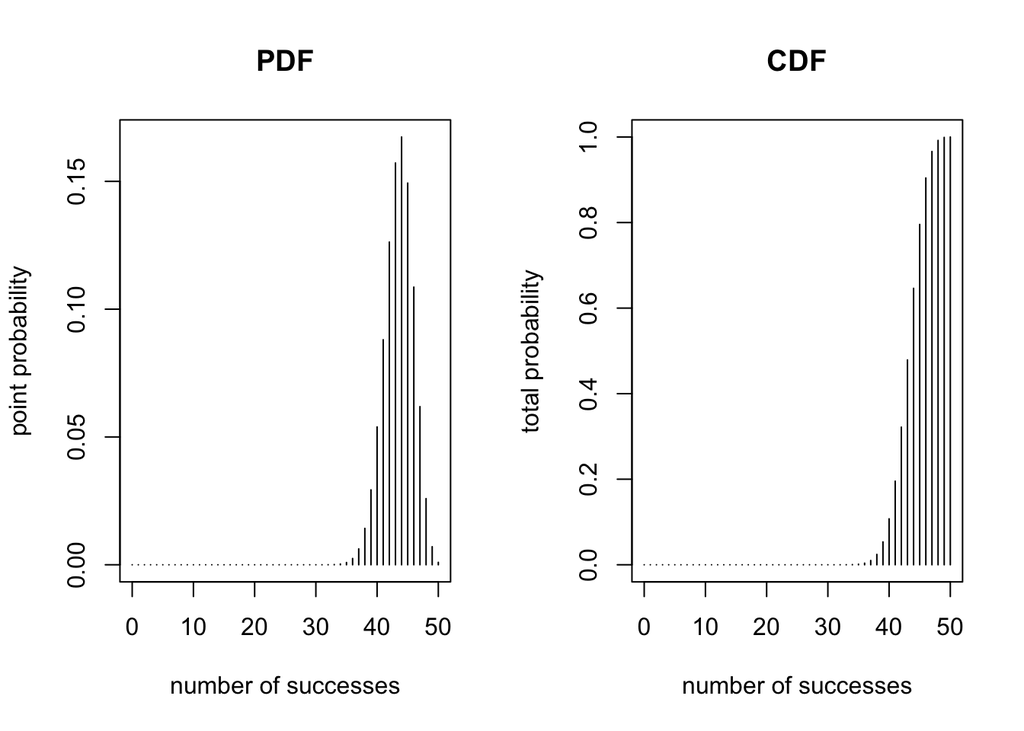

```r
par(mfrow=c(1,2))
x = 0:50
plot(x,dbinom(x,size=50,prob=0.87),type="h",main="PDF",
     xlab="number of successes",ylab="point probability")
plot(x,pbinom(x,size=50,prob=0.87),type="h",main="CDF",
     xlab="number of successes",ylab="total probability")
```

## Binomial distribution (example 2)

Consider a genome in which the four bases $A,C,G,T$ are present in equal proportions (this is actually rather uncommon, but let’s go with it for now).

If you were to pick a sequence of 10nt completely at random, what is the chance that exactly 3 bases will be an $A$ (or any other homopolymer)?

```r
dbinom(3,10,.25)
```

```
## [1] 0.2502823
```

What is the chance that you will find less than 5 $G$s (i.e. 4 or fewer)?

```r
pbinom(4,10,.25)
```

```
## [1] 0.9218731
```

What is the chance that you will find between 2 and 4 $T$s?
$$P(2 \le X \le 4) = \sum_{k=2}^4 {10 \choose k}(0.25)^k(0.75)^{10-k} = \sum_{k=0}^4 {10 \choose k}(0.25)^k(0.75)^{10-k} - \sum_{k=0}^1 {10 \choose k}(0.25)^k(0.75)^{10-k}$$

```r
# these are equivalent: a) sum up the probabilities for all values
sum(dbinom(2:4,10,.25))
```

```
## [1] 0.6778479
```

```r
# b) get the cumulative mass up to and including 4, then
#    subtract the cumulative up to 1 (to get 2 inclusive)
pbinom(4,10,.25) - pbinom(1,10,.25)
```

```
## [1] 0.6778479
```

The quantile function `qbinom(p, size, prob)` returns the smallest value of $q$ such that $Pr(X \le q) \ge p$. The quantile is defined as the smallest value $x$ such that $F(x) \ge p$. For example, $F(x) \ge 0.75$ means that 75% of the distribution is less than $x$. Here, you are likely to find 3 or fewer of each kind of base in 75% of 10-mers picked at random from the genome:

```r
qbinom(.75,10,.25)
```

```
## [1] 3
```

What is the maximum number of any single base you would expect to find in 99% of random 10-mers?

```r
qbinom(.99,10,.25)
```

```
## [1] 6
```

# References

- **Whitlock & Schluter, Chapter 5: Probability**
- **Optional**: *Aho, Foundational and Applied Statistics for Biologists with R*
  - [**Chapter 2**](https://xdas.bio.nyu.edu/references/Aho_Ch2_Intro_Probability.pdf)
  - [**Chapter 3.1-3.2**](https://xdas.bio.nyu.edu/references/Aho_Ch3.1-3.2_PDFs_Part1.pdf)
[^1]: Disclaimer: I made this up, but based on a true story (see https://en.wikipedia.org/wiki/Peppered_moth_evolution).